# Lista 3 - Econometria II

Augusto Floriano, Danyel Lima, Fernando Cruz e Gustavo Darmont

2025-11-05

# Análise visual das séries

[interactive chart not shown]

Visualmente, nota-se que as séries das taxas longa ($R_t$) e curta ($r_t$) exibem trajetórias parecidas, boscilando em torno de um nível médio e sem tendência determinística clara, com prolongada persistência, indicando possivelmente a existência de raiz unitária. O spread ($S_t = R_t - r_t$) apresenta flutuações de menor amplitude, com valores positivos e negativos, sugerindo estacionariedade. Já a variação da taxa curta ($\Delta r_t$) mostra comportamento mais errático, com oscilações pontuais em torno de zero e sem padrão persistente, similar a um ruído branco.

# Análise visual da ACF

[interactive chart not shown]

A ACF do $R_t$ é positiva e indica um decaimento consideravelmente lento, e longo, num ritmo quase que constante, indicando possivelmente a presença de raiz unitária. Da mesma forma, também se observa uma elevada persistência para $r_t$, cruzando a banda superior do limite do intervalo de confiança somente no lag $16$ e indicando a possibilidade de raiz unitária. No ACF do spread, observa-se uma maior oscilação mas ainda com maior parte dos lags fora do intervalo de confiança. Comportamento totalmente distinto se observa no $Δr_t$, com barras menores, quase todas dentro do intervalo de confiança, e aparentando ruido.

# Testes de raiz unitária

```
## $Rt
##
## ###############################################
## # Augmented Dickey-Fuller Test Unit Root Test #
## ###############################################
##
## Test regression drift
##
##
## Call:
## lm(formula = z.diff ~ z.lag.1 + 1 + z.diff.lag)
##
## Residuals:
##     Min      1Q  Median      3Q     Max
## -3.3195 -0.2761 -0.0479  0.2241  2.6973
##
## Coefficients:
##             Estimate Std. Error t value Pr(>|t|)
## (Intercept)  0.18639    0.15113   1.233    0.220
## z.lag.1     -0.04578    0.02932  -1.561    0.121
## z.diff.lag  -0.16284    0.08552  -1.904    0.059 .
## ---
## Signif. codes:  0 '***' 0.001 '**' 0.01 '*' 0.05 '.' 0.1 ' ' 1
##
## Residual standard error: 0.7671 on 137 degrees of freedom
## Multiple R-squared:  0.05071,    Adjusted R-squared:  0.03685
## F-statistic: 3.659 on 2 and 137 DF,  p-value: 0.02831
##
##
## Value of test-statistic is: -1.5614 1.3043
##
## Critical values for test statistics:
##       1pct  5pct 10pct
## tau2 -3.46 -2.88 -2.57
## phi1  6.52  4.63  3.81
##
##
## $rt
##
## ###############################################
```

[output cut: 91 more lines]

```
## z.diff.lag   0.23351    0.08304   2.812  0.00565 **
## ---
## Signif. codes:  0 '***' 0.001 '**' 0.01 '*' 0.05 '.' 0.1 ' ' 1
##
## Residual standard error: 1.559 on 136 degrees of freedom
## Multiple R-squared:  0.5645, Adjusted R-squared:  0.5581
## F-statistic: 88.14 on 2 and 136 DF,  p-value: < 2.2e-16
##
##
## Value of test-statistic is: -10.8973 59.3773
##
## Critical values for test statistics:
##       1pct  5pct 10pct
## tau2 -3.46 -2.88 -2.57
## phi1  6.52  4.63  3.81
```

Três dos quatro modelos não apresentaram intercepto com significância estatística. Dessa forma, a especificação em formato de passeio aleatório foi adotada por ausência de tendência determinística e de intercepto estatisticamente significativo, conforme indicado tanto pela inspeção visual das séries quanto pelos testes sob “drift”, cujos interceptos foram insignificantes.

```
## $Rt
##
## ###############################################
## # Augmented Dickey-Fuller Test Unit Root Test #
## ###############################################
##
## Test regression none
##
##
## Call:
## lm(formula = z.diff ~ z.lag.1 - 1 + z.diff.lag)
##
## Residuals:
##     Min      1Q  Median      3Q     Max
## -3.5746 -0.2006  0.0384  0.2775  2.5038
##
## Coefficients:
##            Estimate Std. Error t value Pr(>|t|)
## z.lag.1    -0.01312    0.01260  -1.041   0.2997
## z.diff.lag -0.18019    0.08451  -2.132   0.0348 *
## ---
## Signif. codes:  0 '***' 0.001 '**' 0.01 '*' 0.05 '.' 0.1 ' ' 1
##
## Residual standard error: 0.7685 on 138 degrees of freedom
## Multiple R-squared:  0.0411, Adjusted R-squared:  0.0272
## F-statistic: 2.957 on 2 and 138 DF,  p-value: 0.05527
##
##
## Value of test-statistic is: -1.041
##
## Critical values for test statistics:
##       1pct  5pct 10pct
## tau1 -2.58 -1.95 -1.62
##
##
## $rt
##
## ###############################################
## # Augmented Dickey-Fuller Test Unit Root Test #
## ###############################################
```

[output cut: 83 more lines]

```
## z.lag.1    -1.32612    0.12152 -10.912  < 2e-16 ***
## z.diff.lag  0.23220    0.08279   2.805  0.00577 **
## ---
## Signif. codes:  0 '***' 0.001 '**' 0.01 '*' 0.05 '.' 0.1 ' ' 1
##
## Residual standard error: 1.555 on 137 degrees of freedom
## Multiple R-squared:  0.5636, Adjusted R-squared:  0.5572
## F-statistic: 88.46 on 2 and 137 DF,  p-value: < 2.2e-16
##
##
## Value of test-statistic is: -10.9124
##
## Critical values for test statistics:
##       1pct  5pct 10pct
## tau1 -2.58 -1.95 -1.62
```

Com o modelo sem intercepto, observa-se a existência de raiz unitária tanto para a taxa longa ($R_t$) quanto para a curta ($r_t$). Contudo, tanto o spread ($S_t$) quanto a diferença na taxa curta ($\Delta_t$) apresentam parâmetro significativo no primeiro lag em nível.

## (e)

Primeiramente, é selecionada uma amostra dos dados de $\Delta R_t$ (primeira diferença da taxa longa) e $\Delta r_t$ (primeira diferença da taxa curta) até 2000. O gráfico abaixo tem por utilidade apenas visualizar de forma breve o comportamento das séries.

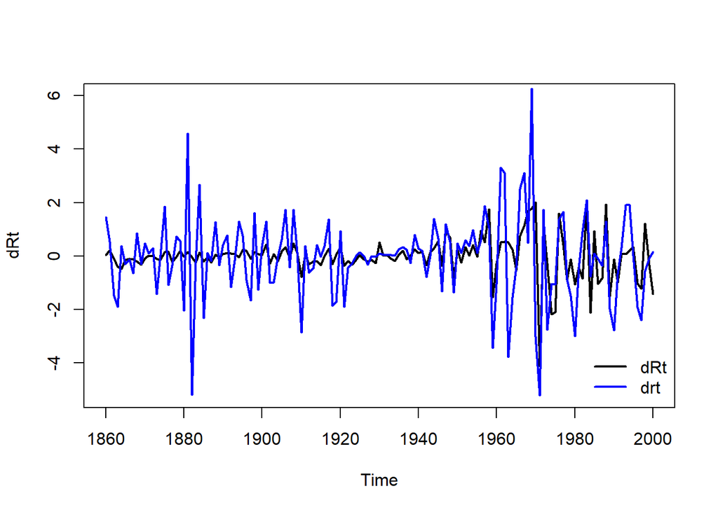

```
## Time Series:
## Start = 1860
## End = 2000
## Frequency = 1
##        dRt    drt
## 1860  0.04  1.460
## 1861  0.22  0.540
## 1862 -0.11 -1.490
## 1863 -0.40 -1.900
## 1864 -0.48  0.370
## 1865 -0.14 -0.300
## 1866 -0.11 -0.130
## 1867 -0.12 -0.650
## 1868 -0.20  0.850
## 1869 -0.32 -0.310
```

[output cut: 131 more lines]

É então aplicado o algoritmo de critérios de seleção para verificar qual p adequado ao modelo VAR(p). Abaixo, observamos que p = 4 realiza o melhor ajuste do modelo.

```
## AIC(n)  HQ(n)  SC(n) FPE(n)
##      4      4      1      4
```

Treinamos então o modelo VAR(4) sobre os dados selecionados das taxas longa e curta.

```
##
## VAR Estimation Results:
## =========================
## Endogenous variables: dRt, drt
## Deterministic variables: const
## Sample size: 137
## Log Likelihood: -356.541
## Roots of the characteristic polynomial:
## 0.7348 0.7348 0.7127 0.7127 0.7074 0.7074 0.6596 0.5667
## Call:
## VAR(y = dados2000, p = 4, type = "const")
##
##
## Estimation results for equation dRt:
## ====================================
## dRt = dRt.l1 + drt.l1 + dRt.l2 + drt.l2 + dRt.l3 + drt.l3 + dRt.l4 + drt.l4 + const
##
##         Estimate Std. Error t value Pr(>|t|)
## dRt.l1 -0.581558   0.110182  -5.278 5.42e-07 ***
## drt.l1  0.289368   0.049350   5.864 3.63e-08 ***
## dRt.l2 -0.206203   0.119605  -1.724   0.0871 .
## drt.l2  0.111977   0.057167   1.959   0.0523 .
## dRt.l3  0.077083   0.118843   0.649   0.5178
## drt.l3  0.090282   0.056144   1.608   0.1103
## dRt.l4  0.204420   0.103170   1.981   0.0497 *
## drt.l4 -0.022462   0.053034  -0.424   0.6726
## const  -0.006117   0.060436  -0.101   0.9195
## ---
## Signif. codes:  0 '***' 0.001 '**' 0.01 '*' 0.05 '.' 0.1 ' ' 1
##
##
## Residual standard error: 0.7052 on 128 degrees of freedom
## Multiple R-Squared: 0.2486,  Adjusted R-squared: 0.2017
## F-statistic: 5.294 on 8 and 128 DF,  p-value: 9.629e-06
##
##
## Estimation results for equation drt:
## ====================================
## drt = dRt.l1 + drt.l1 + dRt.l2 + drt.l2 + dRt.l3 + drt.l3 + dRt.l4 + drt.l4 + const
##
```

[output cut: 14 more lines]

```
## Residual standard error: 1.544 on 128 degrees of freedom
## Multiple R-Squared: 0.119,   Adjusted R-squared: 0.06389
## F-statistic:  2.16 on 8 and 128 DF,  p-value: 0.03475
##
##
##
## Covariance matrix of residuals:
##        dRt    drt
## dRt 0.4973 0.6852
## drt 0.6852 2.3830
##
## Correlation matrix of residuals:
##        dRt    drt
## dRt 1.0000 0.6295
## drt 0.6295 1.0000
```

Uma vez definidos os parâmetros de melhor ajuste, é aplicada a função predict() para projetar os dados de 2001 a 2012 a partir do modelo treinado.

```
## $dRt
##               fcst      lower    upper       CI
##  [1,]  0.771921216 -0.6101792 2.154022 1.382100
##  [2,]  0.212494496 -1.3485370 1.773526 1.561032
##  [3,] -0.316358607 -1.8893132 1.256596 1.572955
##  [4,] -0.095905317 -1.6755073 1.483697 1.579602
##  [5,]  0.151854086 -1.4292675 1.732976 1.581122
##  [6,] -0.113444692 -1.7073213 1.480432 1.593877
##  [7,] -0.064255164 -1.6626975 1.534187 1.598442
##  [8,]  0.047411777 -1.5523001 1.647124 1.599712
##  [9,]  0.009043590 -1.5909424 1.609030 1.599986
## [10,] -0.059397713 -1.6594531 1.540658 1.600055
## [11,] -0.007889211 -1.6082333 1.592455 1.600344
## [12,] -0.003939282 -1.6043540 1.596475 1.600415
##
## $drt
##              fcst     lower    upper       CI
##  [1,]  0.45537742 -2.570219 3.480974 3.025597
##  [2,]  0.29188389 -2.752093 3.335861 3.043977
##  [3,] -0.24015296 -3.395030 2.914724 3.154877
##  [4,] -0.43696584 -3.592331 2.718399 3.155365
##  [5,]  0.06678069 -3.129601 3.263162 3.196381
##  [6,]  0.02018316 -3.184540 3.224906 3.204723
##  [7,] -0.06025710 -3.279384 3.158870 3.219127
##  [8,]  0.04704022 -3.173179 3.267259 3.220219
##  [9,] -0.03274467 -3.253681 3.188192 3.220937
## [10,] -0.09297400 -3.314880 3.128932 3.221906
## [11,] -0.03671171 -3.259590 3.186167 3.222878
## [12,] -0.03143893 -3.254832 3.191954 3.223393
```

Selecionando as séries real e projetada para o período de 2001 a 2012, plotam-se os gráficos e as estatísticas descritivas das séries para que se possa analisar os resultados.

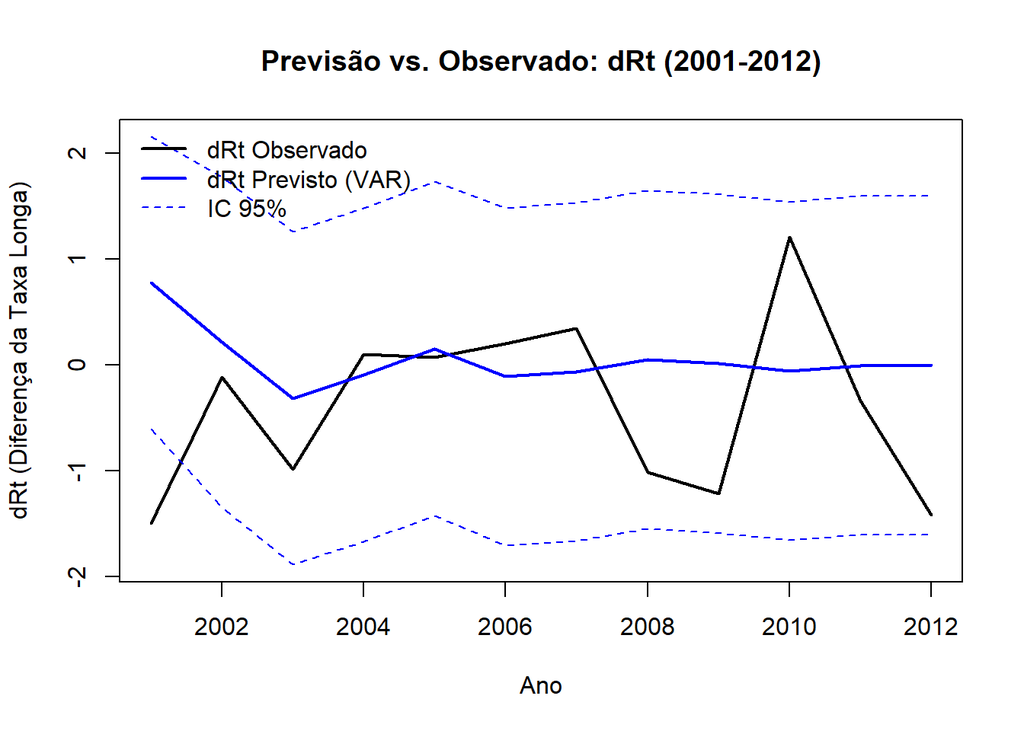

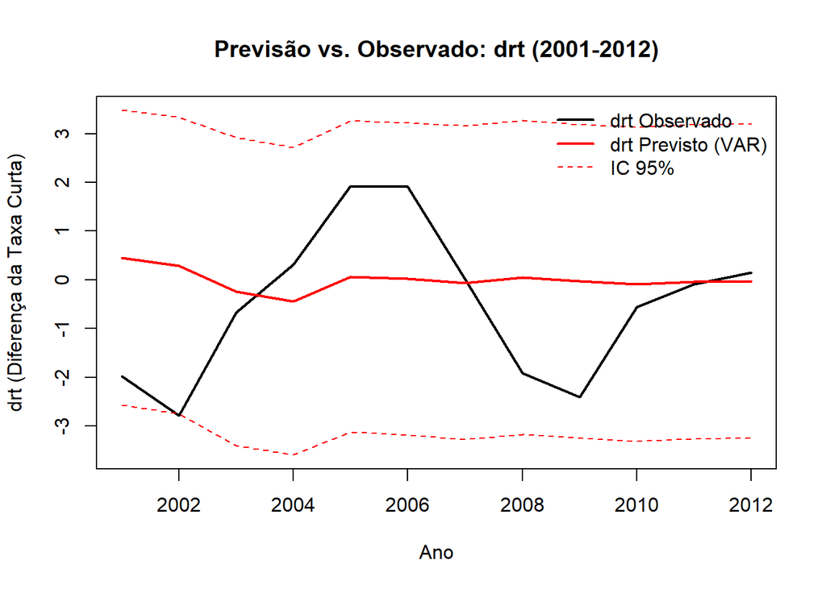

```
## [1] "Estatísticas das Séries"
```

```
##                      Media Desvio_Pad     Minimo    Maximo
## dRt_Observado -0.390833333  0.8370344 -1.5000000 1.2100000
## dRt_Previsto   0.044294598  0.2650465 -0.3163586 0.7719212
## drt_Observado -0.507500000  1.5449088 -2.7800000 1.9200000
## drt_Previsto  -0.004164987  0.2263811 -0.4369658 0.4553774
```

```
## [1] "Largura do IC em h=1 (2001): 2.76420084548527"
```

```
## [1] "Largura do IC em h=12 (2012): 3.2008293630909"
```

A partir da análise gráfica e das estatísticas descritivas, percebe-se uma maior estabilidade dos dados projetados pelo modelo VAR(4) frente aos dados reais de 2001 a 2012.